# Statistical Test in R

2024-05-05

This document presents some simple R functions for some test procedures often adopted in statistical data analysis.

## Test for the mean of one normal population

First, load your data into the R session. You need to specify the path pointing to where your data are stored. The library `readxl` allows you to read excel files. You have to load the library first using the `library` function.

The final command in the following chunk reads the data and saves it in an object called `d` (this is a table called a `dataframe`). In this example, the Excel spreadsheet named `dat1.xlsx` is loaded into the R session. Hereinafter it is assumed the data are located in a folder named “RSession” located in the desktop of your PC. (Please adjust the path to make it consistent to your PC settings).

```r
library(readxl)
d <- read_excel("C:/Users/borgoni/Desktop/RSession/dat1.xlsx")
```

The dataset contains information on a set of patients enrolled in a trial. Assume we want to test if BMI of these patients differs from a commonly accepted value associated with normal health conditions, such as 24.

It is assumed that the BMI follows a normal distribution. Due to the unknown variance, a $t$-test is employed. This test is implemented by the `t.test` function as shown below

```r
x=na.omit(d$BMI)
t.test(x, alternative="two.sided", mu=24)
```

```
##
##  One Sample t-test
##
## data:  x
## t = 4.1705, df = 135, p-value = 5.404e-05
## alternative hypothesis: true mean is not equal to 24
## 95 percent confidence interval:
##  24.93510 26.62181
## sample estimates:
## mean of x
##  25.77846
```

The parameter `mu` specifies the value under $H_0$ whereas `alternative="two.sided"` is used if $H_1: \mu \ne 24$. The p-value is extremely low, indicating that the null hypothesis is not supported by the data and should be rejected.

Note the the $95\%$ confidence interval, also reported in the output, does not include the value of the parameter under the null hypothesis.

A one-sided test can be obtained as it follows

```r
x=na.omit(d$BMI)
t.test(x, alternative="greater", mu=24)
```

```
##
##  One Sample t-test
##
## data:  x
## t = 4.1705, df = 135, p-value = 2.702e-05
## alternative hypothesis: true mean is greater than 24
## 95 percent confidence interval:
##  25.07219      Inf
## sample estimates:
## mean of x
##  25.77846
```

In this case, $H_0$ is contrasted with $H_1: \mu > 24$, implying that the patients may be experiencing overweight.

## Test for the means of two normal populations

The same function can be utilized to test the hypothesis that the two groups of patients have the same mean BMI.

A two-sided test can be conducted using the same function, albeit requiring some data management. Let’s assume we wish to examine whether the BMI is the same for men and women. The R command is as follow

```r
t.test(x=d$BMI[d$Gender=="M"],
       y=d$BMI[d$Gender=="F"],
       alternative="two.sided")
```

```
##
##  Welch Two Sample t-test
##
## data:  d$BMI[d$Gender == "M"] and d$BMI[d$Gender == "F"]
## t = 1.4642, df = 71.901, p-value = 0.1475
## alternative hypothesis: true difference in means is not equal to 0
## 95 percent confidence interval:
##  -0.5192483  3.3918602
## sample estimates:
## mean of x mean of y
##  26.33819  24.90189
```

The command `d$BMI[d$Gender=="M"]` select the subset of the data corresponding to men’s BMI values. `d$BMI[d$Gender=="F"]` serves a similar purpose for women’s data.

```r
var.test(x=d$BMI[d$Gender=="M"],
       y=d$BMI[d$Gender=="F"],
       alternative="two.sided")
```

```
##
##  F test to compare two variances
##
## data:  d$BMI[d$Gender == "M"] and d$BMI[d$Gender == "F"]
## F = 0.29621, num df = 82, denom df = 52, p-value = 8.303e-07
## alternative hypothesis: true ratio of variances is not equal to 1
## 95 percent confidence interval:
##  0.1778989 0.4796870
## sample estimates:
## ratio of variances
##           0.296215
```

In this case this assumption is not supported by the data (small p-value).

## Test for normality

The other assumption for the $t$-test is the normality of the population.

The normality assumption can be “explored” graphically using box-plots and histograms as follows for the variable BMI:

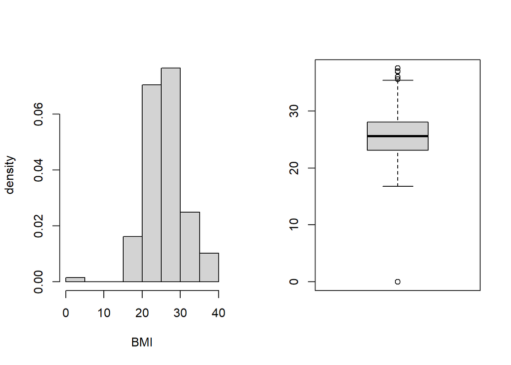

```r
par(mfrow=c(1,2))
hist(d$BMI, xlab="BMI", ylab="density", probability = T, main="")
boxplot(d$BMI)
```

Another useful graph for this purpose is the qq-plot. The plot suggests that the data come from a normal distribution if the sample points tend to align.

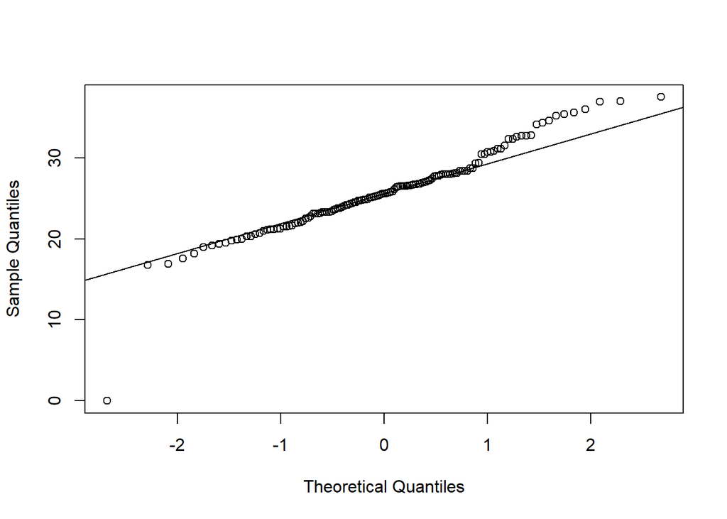

```r
qqnorm(d$BMI, main="")
qqline(d$BMI, main="")
```

If the general trend of the Q–Q plot shows an arc or an S-shape,it indicates that the sample data are skewed or have heavier tails than the normal distribution, suggesting the the Gaussian model may not be appropriate for the data at hand. This appears to be the case with the BMI variable.

Finally normality can be tested via the Shapiro–Wilk test using the following R function

```r
shapiro.test(d$BMI)
```

```
##
##  Shapiro-Wilk normality test
##
## data:  d$BMI
## W = 0.93749, p-value = 9.088e-06
```

The test confirms that the normal model is not adequate for the BMI variable as it was previously noted.

The check should be repeated for each subgroup of males and females before applying the $t$-test to compare the means of the two populations.

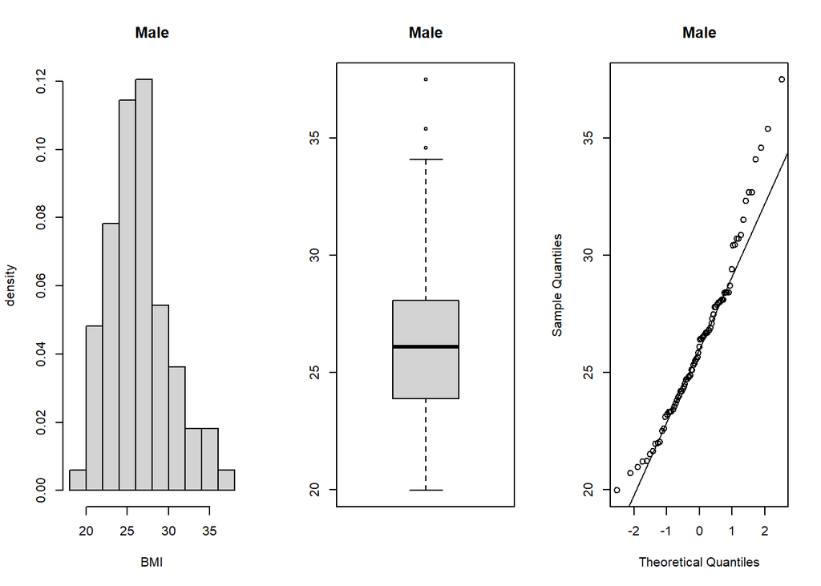

```r
M=d$BMI[d$Gender=="M"]
par(mfrow=c(1,3))
  hist(M, xlab="BMI", ylab="density", probability = T, main="Male")
  boxplot(M, main="Male")
  qqnorm(M, main="Male"); qqline(M)
```

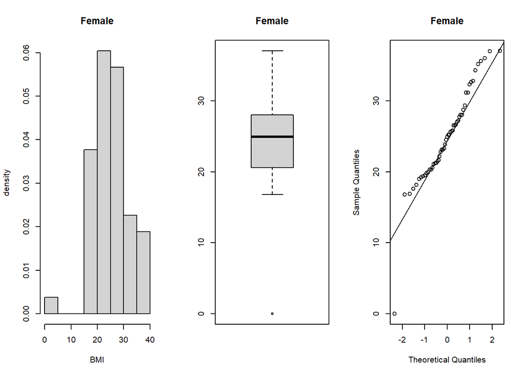

```r
F=d$BMI[d$Gender=="F"]
par(mfrow=c(1,3))
  hist(F, xlab="BMI", ylab="density", probability = T, main="Female")
  boxplot(F, main="Female")
  qqnorm(F, main="Female"); qqline(F)
```

```r
shapiro.test(M)
```

```
##
##  Shapiro-Wilk normality test
##
## data:  M
## W = 0.96033, p-value = 0.01173
```

```r
shapiro.test(F)
```

```
##
##  Shapiro-Wilk normality test
##
## data:  F
## W = 0.93053, p-value = 0.004245
```

The implemented diagnostic does not support normality either for the men and women.

## The Mann-Whitney–Wilcoxon test

In this case would be more appropriate to adopt the Mann-Whitney–Wilcoxon test to evaluate a gender effect on BMI.

This test can be implemented using the following R function:

```r
wilcox.test(x=d$BMI[d$Gender=="M"],
              y=d$BMI[d$Gender=="F"],
              alternative="two.sided")
```

```
##
##  Wilcoxon rank sum test with continuity correction
##
## data:  d$BMI[d$Gender == "M"] and d$BMI[d$Gender == "F"]
## W = 2610.5, p-value = 0.06698
## alternative hypothesis: true location shift is not equal to 0
```

The test does not reject the null hypothesis at the 0.05 significance level (but it does at the 0.1 level ?!….).